# keras

## 線形回帰

```
_________________________________________________________________
Layer (type)                 Output Shape              Param #
=================================================================
dense_2 (Dense)              (None, 1)                 2
=================================================================
Total params: 2
Trainable params: 2
Non-trainable params: 0
_________________________________________________________________
Generation: 10. 誤差 = 3.84822
Generation: 20. 誤差 = 2.786099
Generation: 30. 誤差 = 2.0496964
Generation: 40. 誤差 = 1.5341984
Generation: 50. 誤差 = 1.1691959
Generation: 60. 誤差 = 0.9073013
Generation: 70. 誤差 = 0.7165442
Generation: 80. 誤差 = 0.5752908
Generation: 90. 誤差 = 0.46884364
Generation: 100. 誤差 = 0.38716865
Generation: 110. 誤差 = 0.32337275
Generation: 120. 誤差 = 0.2726847
Generation: 130. 誤差 = 0.23177084
Generation: 140. 誤差 = 0.1982766
Generation: 150. 誤差 = 0.1705169
Generation: 160. 誤差 = 0.14726795
Generation: 170. 誤差 = 0.12762651
Generation: 180. 誤差 = 0.11091433
Generation: 190. 誤差 = 0.09661263
Generation: 200. 誤差 = 0.084317714
Generation: 210. 誤差 = 0.07370969
Generation: 220. 誤差 = 0.064531215
Generation: 230. 誤差 = 0.056572083
Generation: 240. 誤差 = 0.04965852
Generation: 250. 誤差 = 0.04364519
Generation: 260. 誤差 = 0.038409553
Generation: 270. 誤差 = 0.03384745
Generation: 280. 誤差 = 0.029869832
Generation: 290. 誤差 = 0.026400214
Generation: 300. 誤差 = 0.023372656
Generation: 310. 誤差 = 0.020730095
```

[output cut: 56 more lines]

```
Generation: 880. 誤差 = 0.002511172
Generation: 890. 誤差 = 0.0025101318
Generation: 900. 誤差 = 0.0025092242
Generation: 910. 誤差 = 0.0025084305
Generation: 920. 誤差 = 0.0025077367
Generation: 930. 誤差 = 0.002507131
Generation: 940. 誤差 = 0.0025066016
Generation: 950. 誤差 = 0.0025061397
Generation: 960. 誤差 = 0.002505736
Generation: 970. 誤差 = 0.0025053835
Generation: 980. 誤差 = 0.0025050754
Generation: 990. 誤差 = 0.002504806
Generation: 1000. 誤差 = 0.002504571
W: [[0.49509984]]
b: [2.0056722]
```

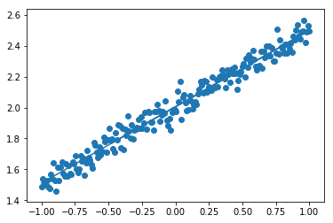

```python
import numpy as np
import matplotlib.pyplot as plt

iters_num = 1000
plot_interval = 10

x = np.linspace(-1, 1, 200)
np.random.shuffle(x)
d = 0.5 * x + 2 + np.random.normal(0, 0.05, (200,))

from keras.models import Sequential
from keras.layers import Dense

# モデルを作成
model = Sequential()
model.add(Dense(input_dim=1, output_dim=1))

# モデルを表示
model.summary()

# モデルのコンパイル
model.compile(loss='mse', optimizer='sgd')

# train
for i in range(iters_num):
    loss = model.train_on_batch(x, d)
    if (i+1) % plot_interval == 0:
        print('Generation: ' + str(i+1) + '. 誤差 = ' + str(loss))

W, b = model.layers[0].get_weights()
print('W:', W)
print('b:', b)

y = model.predict(x)
plt.scatter(x, d)
plt.plot(x, y)
plt.show()
```

## 単純パーセプトロン

OR回路

### [try]

- np.random.seed(0)をnp.random.seed(1)に変更
- エポック数を100に変更
- AND回路, XOR回路に変更
- OR回路にしてバッチサイズを10に変更
- エポック数を300に変更しよう

```python
# モジュール読み込み
import numpy as np
from keras.models import Sequential
from keras.layers import Dense, Activation
from keras.optimizers import SGD

# 乱数を固定値で初期化
# np.random.seed(0)    # default
np.random.seed(1)
#
# シグモイドの単純パーセプトロン作成
model = Sequential()
# model.add(Dense(input_dim=2, units=1))  # default
model.add(Dense(input_dim=2, units=4, activation='relu'))
model.add(Dense(1))
model.add(Activation('sigmoid')) # default
# model.add(Activation('relu'))
model.summary()

model.compile(loss='binary_crossentropy', optimizer=SGD(lr=0.1))

# トレーニング用入力 X と正解データ T
# for AND
# X = np.array( [[0,0], [0,1], [1,0], [1,1]] )
# T = np.array( [[0], [0], [0], [1]] )
# for Xor
X = np.array( [[0,0], [0,1], [1,0], [1,1]] )
T = np.array( [[0], [1], [1], [0]] )

# トレーニング
# model.fit(X, T, epochs=30, batch_size=1)
model.fit(X, T, epochs=300, batch_size=10)


# トレーニングの入力を流用して実際に分類
Y = model.predict_classes(X, batch_size=1)

print("TEST")
print(Y == T)
```

```
_________________________________________________________________
Layer (type)                 Output Shape              Param #
=================================================================
dense_34 (Dense)             (None, 4)                 12
_________________________________________________________________
dense_35 (Dense)             (None, 1)                 5
_________________________________________________________________
activation_23 (Activation)   (None, 1)                 0
=================================================================
Total params: 17
Trainable params: 17
Non-trainable params: 0
_________________________________________________________________
TEST
[[ True]
 [ True]
 [ True]
 [ True]]
```

(考察)

- seedを変えると初期値が変わるので、いくつか試すとよい。
- 1層のパーセプトロンは線形しかっ用言できない。
- 2層化(1層目層 units=4, activation='relu')で実現可能。

AND -sigmoid seed(1)  
[[ True] [ True] [ True] [ True]]

XOR -sigmoid seed(1)  
[[ True] [False] [ True] [False]]

XOR -relu seed(1)  
[[ True] [False] [False] [ True]]

## 分類 (iris)

### [try]

- 中間層の活性関数をsigmoidに変更しよう
- SGDをimportしoptimizerをSGD(lr=0.1)に変更しよう

```
_________________________________________________________________
Layer (type)                 Output Shape              Param #
=================================================================
dense_58 (Dense)             (None, 12)                60
_________________________________________________________________
activation_46 (Activation)   (None, 12)                0
_________________________________________________________________
dense_59 (Dense)             (None, 3)                 39
_________________________________________________________________
activation_47 (Activation)   (None, 3)                 0
=================================================================
Total params: 99
Trainable params: 99
Non-trainable params: 0
_________________________________________________________________
Train on 120 samples, validate on 30 samples
```

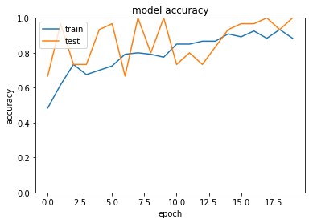

```python
import matplotlib.pyplot as plt
from sklearn import datasets
iris = datasets.load_iris()

from keras.optimizers import SGD

x = iris.data
d = iris.target

# from sklearn.cross_validation import train_test_split
# x_train, x_test, d_train, d_test = train_test_split(x, d, test_size=0.2)
from sklearn.model_selection import train_test_split
x_train, x_test, d_train, d_test = train_test_split(x, d, test_size=0.2)

from keras.models import Sequential
from keras.layers import Dense, Activation
from keras.optimizers import SGD

#モデルの設定
model = Sequential()
model.add(Dense(12, input_dim=4))
# model.add(Activation('relu'))   # default
model.add(Activation('sigmoid'))
model.add(Dense(3, input_dim=12))
model.add(Activation('softmax'))
model.summary()

# model.compile(optimizer='sgd', loss='sparse_categorical_crossentropy', metrics=['accuracy'])
model.compile(optimizer=SGD(lr=0.1), loss='sparse_categorical_crossentropy', metrics=['accuracy'])

history = model.fit(x_train, d_train, batch_size=5, epochs=20, verbose=1, validation_data=(x_test, d_test))
loss = model.evaluate(x_test, d_test, verbose=0)

#Accuracy
plt.plot(history.history['acc'])
plt.plot(history.history['val_acc'])
plt.title('model accuracy')
plt.ylabel('accuracy')
plt.xlabel('epoch')
plt.legend(['train', 'test'], loc='upper left')
plt.ylim(0, 1.0)
plt.show()
```

【考察】  
sigomid,SGD(lr=0.1)が一番よい結果を得た。

- Activation('relu'), optimizer='sgd'  
  loss: 0.3211 - acc: 0.9250 - val_loss: 0.2515 - val_acc: 0.9667
- Activation('sigmoid'), optimizer='sgd'  
  loss: 0.7635 - acc: 0.7167 - val_loss: 0.7473 - val_acc: 0.7333
- Activation('relu'), optimizer='SGD(lr=0.1)'  
  loss: 0.3022 - acc: 0.8833 - val_loss: 0.1000 - val_acc: 0.9667
- Activation('sigmoid'), optimizer='SGD(lr=0.1)'  
  loss: 0.3546 - acc: 0.8833 - val_loss: 0.2490 - val_acc: 1.0000

## 分類 (mnist)

### [try]

- load_mnistのone_hot_labelをFalseに変更しよう (error)
- 誤差関数をsparse_categorical_crossentropyに変更しよう
- Adamの引数の値を変更しよう

```python
# 必要なライブラリのインポート
import sys, os
sys.path.append(os.pardir)  # 親ディレクトリのファイルをインポートするための設定
import keras
import matplotlib.pyplot as plt
from data.mnist import load_mnist

# (x_train, d_train), (x_test, d_test) = load_mnist(normalize=True, one_hot_label=True)   # default
(x_train, d_train), (x_test, d_test) = load_mnist(normalize=True, one_hot_label=False)
print(x_train.shape, d_train.shape, x_test.shape, d_test.shape)

# 件数を減らす
x_train = x_train[:3000]
d_train = d_train[:3000]
x_test = x_test[:500]
d_test = d_test[:500]
print(x_train.shape, d_train.shape, x_test.shape, d_test.shape)
```

```
(60000, 784) (60000,) (10000, 784) (10000,)
(3000, 784) (3000,) (500, 784) (500,)
```

```
_________________________________________________________________
Layer (type)                 Output Shape              Param #
=================================================================
dense_114 (Dense)            (None, 512)               401920
_________________________________________________________________
dropout_37 (Dropout)         (None, 512)               0
_________________________________________________________________
dense_115 (Dense)            (None, 512)               262656
_________________________________________________________________
dropout_38 (Dropout)         (None, 512)               0
_________________________________________________________________
dense_116 (Dense)            (None, 10)                5130
=================================================================
Total params: 669,706
Trainable params: 669,706
Non-trainable params: 0
_________________________________________________________________
Train on 3000 samples, validate on 500 samples
Test loss: 14.731938957214355
Test accuracy: 0.08600000002980232
```

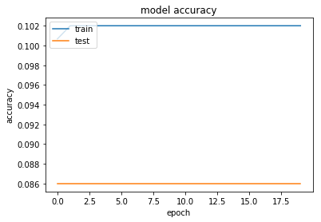

```python
# 必要なライブラリのインポート、最適化手法はAdamを使う
from keras.models import Sequential
from keras.layers import Dense, Dropout
from keras.optimizers import Adam

# モデル作成
model = Sequential()
model.add(Dense(512, activation='relu', input_shape=(784,)))
model.add(Dropout(0.2))
model.add(Dense(512, activation='relu'))
model.add(Dropout(0.2))
model.add(Dense(10, activation='softmax'))
model.summary()

# バッチサイズ、エポック数
batch_size = 128
epochs = 20

# model.compile(loss='categorical_crossentropy',
#               optimizer=Adam(lr=0.001, beta_1=0.9, beta_2=0.999, epsilon=None, decay=0.0, amsgrad=False),
#               metrics=['accuracy'])
model.compile(loss='sparse_categorical_crossentropy',
              optimizer=Adam(lr=0.1, beta_1=0.9, beta_2=0.999, epsilon=None, decay=0.0, amsgrad=False),
              metrics=['accuracy'])

history = model.fit(x_train, d_train, batch_size=batch_size, epochs=epochs, verbose=1, validation_data=(x_test, d_test))
loss = model.evaluate(x_test, d_test, verbose=0)
print('Test loss:', loss[0])
print('Test accuracy:', loss[1])
#Accuracy
plt.plot(history.history['acc'])
plt.plot(history.history['val_acc'])
plt.title('model accuracy')
plt.ylabel('accuracy')
plt.xlabel('epoch')
plt.legend(['train', 'test'], loc='upper left')
# plt.ylim(0, 1.0)
plt.show()
```

【実行結果】  
one_hot_label=True, loss='categorical_crossentropy'  
optimizer=Adam(lr=0.001, beta_1=0.9, beta_2=0.999, epsilon=None, decay=0.0, amsgrad=False)  
loss: 0.0066 - acc: 0.9987 - val_loss: 0.2148 - val_acc: 0.9500

one_hot_label=False, loss='sparse_categorical_crossentropy'  
optimizer=Adam(lr=0.001, beta_1=0.9, beta_2=0.999, epsilon=None, decay=0.0, amsgrad=False)  
loss: 0.0049 - acc: 0.9997 - val_loss: 0.1860 - val_acc: 0.9460

one_hot_label=False, loss='sparse_categorical_crossentropy'  
optimizer=Adam(lr=0.01, beta_1=0.9, beta_2=0.999, epsilon=None, decay=0.0, amsgrad=False)  
loss: 0.1959 - acc: 0.9620 - val_loss: 0.4421 - val_acc: 0.9300

【考察】

- 学習率(lr=0.01)を挙げると学習速度が上がったが、上げすぎる(lr=0.1)と、精度が出なくなった。

## CNN分類 (mnist)

#### 実行に時間がかかるため割愛

```
_________________________________________________________________
Layer (type)                 Output Shape              Param #
=================================================================
conv2d_5 (Conv2D)            (None, 28, 28, 32)        320
_________________________________________________________________
conv2d_6 (Conv2D)            (None, 28, 28, 64)        18496
_________________________________________________________________
max_pooling2d_3 (MaxPooling2 (None, 14, 14, 64)        0
_________________________________________________________________
dropout_42 (Dropout)         (None, 14, 14, 64)        0
_________________________________________________________________
flatten_2 (Flatten)          (None, 12544)             0
_________________________________________________________________
dense_119 (Dense)            (None, 128)               1605760
_________________________________________________________________
dropout_43 (Dropout)         (None, 128)               0
_________________________________________________________________
dense_120 (Dense)            (None, 10)                1290
=================================================================
Total params: 1,625,866
Trainable params: 1,625,866
Non-trainable params: 0
_________________________________________________________________
Train on 1000 samples, validate on 1000 samples
```

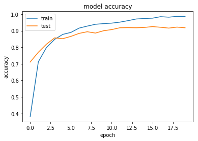

```python
# 必要なライブラリのインポート
import sys, os
sys.path.append(os.pardir)  # 親ディレクトリのファイルをインポートするための設定
import keras
import matplotlib.pyplot as plt
from data.mnist import load_mnist

(x_train, d_train), (x_test, d_test) = load_mnist(normalize=True, one_hot_label=True)

x_train = x_train[:1000]
d_train = d_train[:1000]
x_test = x_test[:1000]
d_test = d_test[:1000]

# 行列として入力するための加工
batch_size = 128
num_classes = 10
epochs = 20

img_rows, img_cols = 28, 28

x_train = x_train.reshape(x_train.shape[0], img_rows, img_cols, 1)
x_test = x_test.reshape(x_test.shape[0], img_rows, img_cols, 1)
input_shape = (img_rows, img_cols, 1)


# 必要なライブラリのインポート、最適化手法はAdamを使う
from keras.models import Sequential
from keras.layers import Dense, Dropout, Flatten
from keras.layers import Conv2D, MaxPooling2D
from keras.optimizers import Adam

model = Sequential()
model.add(Conv2D(32, kernel_size=(3, 3),
                 activation='relu',
                 padding='same',
                 input_shape=input_shape))
model.add(Conv2D(64, (3, 3), padding='same', activation='relu'))
model.add(MaxPooling2D(pool_size=(2, 2)))
model.add(Dropout(0.25))
model.add(Flatten())
model.add(Dense(128, activation='relu'))
model.add(Dropout(0.5))
model.add(Dense(num_classes, activation='softmax'))
model.summary()

# バッチサイズ、エポック数
batch_size = 128
epochs = 20

model.compile(loss='categorical_crossentropy', optimizer=Adam(), metrics=['accuracy'])
history = model.fit(x_train, d_train, batch_size=batch_size, epochs=epochs, verbose=1, validation_data=(x_test, d_test))

#Accuracy
plt.plot(history.history['acc'])
plt.plot(history.history['val_acc'])
plt.title('model accuracy')
plt.ylabel('accuracy')
plt.xlabel('epoch')
plt.legend(['train', 'test'], loc='upper left')
# plt.ylim(0, 1.0)
plt.show()
```

## cifar10

#### 実行に時間がかかるため割愛

データセット cifar10  
32x32ピクセルのカラー画像データ  
10種のラベル「飛行機、自動車、鳥、猫、鹿、犬、蛙、馬、船、トラック」  
トレーニングデータ数:50000, テストデータ数:10000  
http://www.cs.toronto.edu/~kriz/cifar.html

```python
#CIFAR-10のデータセットのインポート
import sys
sys.path.append('..')
from keras.datasets import cifar10
(x_train, d_train), (x_test, d_test) = cifar10.load_data()
```

```python
print(x_train.shape)
```

```
(50000, 32, 32, 3)
```

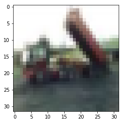

```python
import matplotlib.pyplot as plt
plt.imshow(x_train[2])
```

```python
from keras.utils import to_categorical

test_data = d_train[0]
print(test_data)
test_data_one_hot = to_categorical(test_data, 10)
print(test_data_one_hot)
```

```
[6]
[[0. 0. 0. 0. 0. 0. 1. 0. 0. 0.]]
```

```python
#CIFAR-10のデータセットのインポート
from keras.datasets import cifar10
(x_train, d_train), (x_test, d_test) = cifar10.load_data()
x_train = x_train[:1000]
d_train = d_train[:1000]
x_test = x_test[:1000]
d_test = d_test[:1000]


#CIFAR-10の正規化
from keras.utils import to_categorical

# 特徴量の正規化
x_train = x_train/255.
x_test = x_test/255.

# クラスラベルの1-hotベクトル化
d_train = to_categorical(d_train, 10)
d_test = to_categorical(d_test, 10)

# CNNの構築
import keras
from keras.models import Sequential
from keras.layers.convolutional import Conv2D, MaxPooling2D
from keras.layers.core import Dense, Dropout, Activation, Flatten
from keras.layers import BatchNormalization
import numpy as np

model = Sequential()

model.add(Conv2D(32, (3, 3), padding='same',input_shape=x_train.shape[1:]))
model.add(BatchNormalization())
model.add(Activation('relu'))
model.add(Conv2D(32, (3, 3)))
model.add(Activation('relu'))
model.add(MaxPooling2D(pool_size=(2, 2)))
model.add(Dropout(0.25))

model.add(Conv2D(64, (3, 3), padding='same'))
model.add(Activation('relu'))
model.add(Conv2D(64, (3, 3)))
model.add(Activation('relu'))
model.add(MaxPooling2D(pool_size=(2, 2)))
model.add(Dropout(0.25))

model.add(Flatten())
model.add(Dense(512))
model.add(Activation('relu'))
model.add(Dropout(0.5))
model.add(Dense(10))
model.add(Activation('softmax'))

# コンパイル
model.compile(loss='categorical_crossentropy',optimizer='adam',metrics=['accuracy'])

#訓練
history = model.fit(x_train, d_train, epochs=3, validation_data=(x_test, d_test))

# モデルの保存
model.save('./CIFAR-10.h5')

#評価 & 評価結果出力
print(model.evaluate(x_test, d_test))
```

```
Train on 1000 samples, validate on 1000 samples
[1.8797801246643067, 0.299]
```

```python
# CNNの構築
import keras
from keras.models import Sequential
from keras.layers.convolutional import Conv2D, MaxPooling2D
from keras.layers.core import Dense, Dropout, Activation, Flatten
from keras.layers import BatchNormalization
import numpy as np

model = Sequential()

model.add(Conv2D(32, (3, 3), padding='same',input_shape=x_train.shape[1:]))
model.add(BatchNormalization())
model.add(Activation('relu'))
model.add(Conv2D(32, (3, 3)))
model.add(Activation('relu'))
model.add(MaxPooling2D(pool_size=(2, 2)))
model.add(Dropout(0.25))

model.add(Conv2D(64, (3, 3), padding='same'))
model.add(Activation('relu'))
model.add(Conv2D(64, (3, 3)))
model.add(Activation('relu'))
model.add(MaxPooling2D(pool_size=(2, 2)))
model.add(Dropout(0.25))

model.add(Flatten())
model.add(Dense(512))
model.add(Activation('relu'))
model.add(Dropout(0.5))
model.add(Dense(10))
model.add(Activation('softmax'))

# コンパイル
model.compile(loss='categorical_crossentropy',optimizer='adam',metrics=['accuracy'])

# #訓練
# history = model.fit(x_train, d_train, epochs=3, validation_data=(x_test, d_test))

# モデルの保存
# model.save('./CIFAR-10.h5')

#評価 & 評価結果出力
print(model.evaluate(x_test, d_test))
```

```
[2.2997166213989257, 0.104]
```

```python
model.load_weights('./CIFAR-10.h5')
print(model.evaluate(x_test, d_test))
```

```
[1.8797801246643067, 0.299]
```

## RNN

2進数足し算の予測

Keras RNNのドキュメント https://keras.io/ja/layers/recurrent/#simplernn

### [try]

- RNNの出力ノード数を128に変更
- RNNの出力活性化関数を sigmoid に変更
- RNNの出力活性化関数を tanh に変更
- 最適化方法をadamに変更
- RNNの入力 Dropout を0.5に設定
- RNNの再帰 Dropout を0.3に設定
- RNNのunrollをTrueに設定

```python
import sys, os
sys.path.append(os.pardir)  # 親ディレクトリのファイルをインポートするための設定
import numpy as np
import matplotlib.pyplot as plt

import keras
from keras.models import Sequential
from keras.layers.core import Dense, Dropout,Activation
from keras.layers.wrappers import TimeDistributed
from keras.optimizers import SGD
from keras.layers.recurrent import SimpleRNN, LSTM, GRU


# データを用意
# 2進数の桁数
binary_dim = 8
# 最大値 + 1
largest_number = pow(2, binary_dim)

# largest_numberまで2進数を用意
binary = np.unpackbits(np.array([range(largest_number)], dtype=np.uint8).T,axis=1)[:, ::-1]


# A, B初期化 (a + b = d)
a_int = np.random.randint(largest_number/2, size=20000)
a_bin = binary[a_int] # binary encoding
b_int = np.random.randint(largest_number/2, size=20000)
b_bin = binary[b_int] # binary encoding

x_int = []
x_bin = []
for i in range(10000):
    x_int.append(np.array([a_int[i], b_int[i]]).T)
    x_bin.append(np.array([a_bin[i], b_bin[i]]).T)

x_int_test = []
x_bin_test = []
for i in range(10001, 20000):
    x_int_test.append(np.array([a_int[i], b_int[i]]).T)
    x_bin_test.append(np.array([a_bin[i], b_bin[i]]).T)

x_int = np.array(x_int)
x_bin = np.array(x_bin)
x_int_test = np.array(x_int_test)
x_bin_test = np.array(x_bin_test)


# 正解データ
d_int = a_int + b_int
d_bin = binary[d_int][0:10000]
d_bin_test = binary[d_int][10001:20000]

model = Sequential()

# For SimpleRNN
# model.add(SimpleRNN(units=16,  # NO.1  16 → 128に変更
#                return_sequences=True,
#                input_shape=[8, 2],
#                go_backwards=False,
#                activation='relu',
# #                activation='sigmoid', # No,2 relu → sigmoid
# #                activation='tanh', # No,3 relu → tanh
#                dropout=0.5,
#                recurrent_dropout=0.3,
#                unroll = True,
#             ))
# For GRU
# model.add(GRU(units=16,  # NO.1  16 → 128に変更
#                return_sequences=True,
#                input_shape=[8, 2],
#                go_backwards=False,
#                activation='relu',
# #                activation='sigmoid', # No,2 relu → sigmoid
# #                activation='tanh', # No,3 relu → tanh
#                dropout=0.5,
#                recurrent_dropout=0.3,
#                unroll = True,
#             ))

# For GRU
model.add(LSTM(units=16,  # NO.1  16 → 128に変更
               return_sequences=True,
               input_shape=[8, 2],
               go_backwards=False,
               activation='relu',
#                activation='sigmoid', # No,2 relu → sigmoid
#                activation='tanh', # No,3 relu → tanh
               dropout=0.5,
               recurrent_dropout=0.3,
               unroll = True,
            ))



# 出力層
model.add(Dense(1, activation='sigmoid', input_shape=(-1,2)))
model.summary()
# model.compile(loss='mean_squared_error', optimizer=SGD(lr=0.1), metrics=['accuracy'])
model.compile(loss='mse', optimizer='adam', metrics=['accuracy'])  #No,4 Optimizer SGD→Afamへ

history = model.fit(x_bin, d_bin.reshape(-1, 8, 1), epochs=5, batch_size=2)

# テスト結果出力
score = model.evaluate(x_bin_test, d_bin_test.reshape(-1,8,1), verbose=0)
print('Test loss:', score[0])
print('Test accuracy:', score[1])
```

```
_________________________________________________________________
Layer (type)                 Output Shape              Param #
=================================================================
lstm_1 (LSTM)                (None, 8, 16)             1216
_________________________________________________________________
dense_129 (Dense)            (None, 8, 1)              17
=================================================================
Total params: 1,233
Trainable params: 1,233
Non-trainable params: 0
_________________________________________________________________
Test loss: 0.02470334995258944
Test accuracy: 0.9993374337433744
```